# R Notebook

Das Würfelwurfexperiment wird mehrmals durchgeführt und dann die Statistik daraus berechnet.

```r
round_to_nearest_power_of_10 <- function(x, floor_value=FALSE) {
  if(x <= 0){
    stop("Value was smaller or equal to zero. Cannot round.")
  }
  if(floor_value){
    power_of_10 <- floor(log10(x))
  }else{
    power_of_10 <- ceiling(log10(x))
  }
  rounded_value <- round(x / 10^power_of_10) * 10^power_of_10
  return(rounded_value)
}
```

# 1)

Simulation von Münzwürfen. Es werden 500 Experimente mit je 100 Würfen durchgeführt. Diese werden dann in der Schleife ausgewertet.

```r
experiment_zähler <- 500
mehr_als_3.vec <- c()
for(i in 1:experiment_zähler){
  N <- 100
  münzwurf.vec <- floor(runif(N, 0, 2))
  münzwurf.vec

  mehr_als_3 <- 0
  eintrag <- münzwurf.vec[1]
  hintereinander <- 0
  for (wurf in münzwurf.vec){
    if (wurf != eintrag){
      hintereinander <- 1
    }
    else{
      hintereinander = hintereinander + 1
      eintrag <- wurf
    }
    if(hintereinander == 3){
      mehr_als_3 = mehr_als_3 + 1
    }
  }
  mehr_als_3.vec <- c(mehr_als_3.vec, mehr_als_3)
}
```

Mittelwert des Vorkommnisses:

```r
mean(mehr_als_3.vec)
```

```
## [1] 12.282
```

Standardabweichung:

```r
sd(mehr_als_3.vec)
```

```
## [1] 2.093619
```

## Würfelwurf

```r
experiment_zähler <- 15000
mehr_als_3_6er_6er.vec <- c()
for(i in 1:experiment_zähler){
  N <- 100
  würfelwurf.vec <- floor(runif(N, 1, 7))
  sechser.vec <- c()
  for (wurf in würfelwurf.vec){
    if(wurf == 6){
      sechser.vec <- c(sechser.vec, 1)
    }else
    {
      sechser.vec <- c(sechser.vec, 0)
    }
  }

  mehr_als_3_6er <- 0
  eintrag <- sechser.vec[1]
  hintereinander <- 0
  for (wurf in sechser.vec){
    if (wurf != eintrag){
      hintereinander <- 1
    }
    else{
      hintereinander = hintereinander + 1
      eintrag <- wurf
    }
    if(hintereinander == 3 && wurf == 1){
      mehr_als_3_6er = mehr_als_3_6er + 1
    }
  }
  mehr_als_3_6er_6er.vec <- c(mehr_als_3_6er_6er.vec, mehr_als_3_6er)
}
# mehr_als_3_6er_6er.vec
```

Statistische Wahrscheinlichkeit der Häufigkeit von 6er in Serie Mittelwert

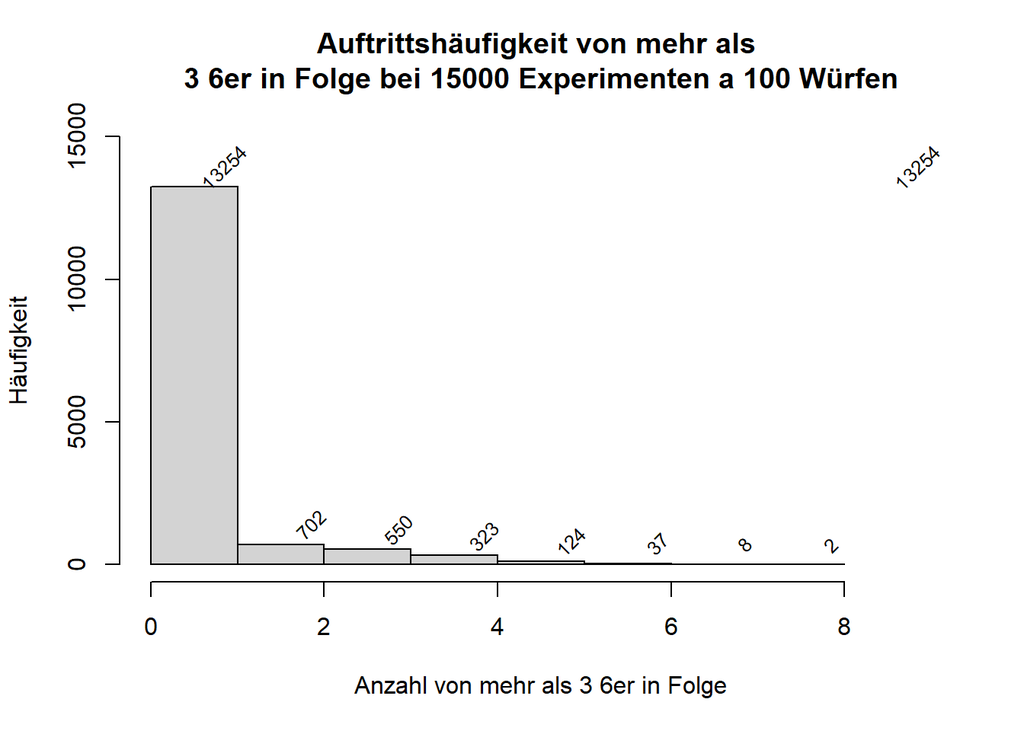

```r
# Die Häufigkeit, wie oft mehr als 3 6er hintereinander kommen werden ignoriert. Es werden nur die Serien ungleich null für die Aussage verwendet
mehr_als_3_6er_6er.count = 0
for (i in mehr_als_3_6er_6er.vec){
  if (i != 0){
    mehr_als_3_6er_6er.count = mehr_als_3_6er_6er.count + 1
  }
}
h = hist(mehr_als_3_6er_6er.vec, breaks = c(0:max(mehr_als_3_6er_6er.vec)), ylim = c(0, 15000), xlim = c(0, 9)
     ,main = "Auftrittshäufigkeit von mehr als \n3 6er in Folge bei 15000 Experimenten a 100 Würfen"
     ,ylab = "Häufigkeit"
     ,xlab = "Anzahl von mehr als 3 6er in Folge")
text(x = h$breaks + 0.9, y=h$counts, labels = h$counts, pos=3, cex=.80, srt=45)
```

Mittelwert

```r
mehr_als_3_6er_6er.count / experiment_zähler
```

```
## [1] 0.1560667
```

Bedeutet, erst in etwa jeder 6ten bis 7ten Serie von 100 Würfelwürfen kommen mehr als 3 6er in Folge vor.

## Monte Carlo Simulation

Für die Berechnung folgt hier die Erklärung der Flächenverhältnisse.

$$Kreisfläche: A_{k} = r^2\cdot\pi \\
Quadratfläche: A_{q} = s^2\\
Verhältnis: V=\frac{A_{k}}{A_{q}}\\
mit\,s=2,\,r=1\\
V=\frac{r^2\cdot\pi}{s^2}=\frac{1\cdot\pi}{4}\\
\pi=4 \cdot V$$

```r
N.vec <- 10^(seq(2,9,1)) # logartithmischer Anstieg der Zahlenfolge

Q.vec <- c()

for(N in  N.vec){
  set.seed(10000)
  z.vec <- runif(N, -1, 1)
  m <- N/2
  x.vec <- z.vec[1:m]
  y.vec <- z.vec[(m+1):N]
  Q <- 0
  for (i in 1:m){
    if(sqrt(x.vec[i]^2 + y.vec[i]^2) < 1){
      Q = Q + 1
    }
  }
  remove(x.vec, y.vec, z.vec)
  gc()
  Q.vec <- c(Q.vec, Q)
}
Q.vec
```

```
## [1]        40       397      3947     39295    392835   3926260  39273227
## [8] 392694042
```

Q.vec hat nun die Punkteanzahl, welche im Kreis lagen. Gilt für jede Anzahl der Zufallszahlen in N.vec. N.vec/2 entspricht der Anzahl der Punkte die sich im Quadrat befinden. Es wird das Verhältnis berechnet und anschließend die Abweichung zu Pi in Abhängigkeit der Anzahl der Zufallsgrößen dargestellt.

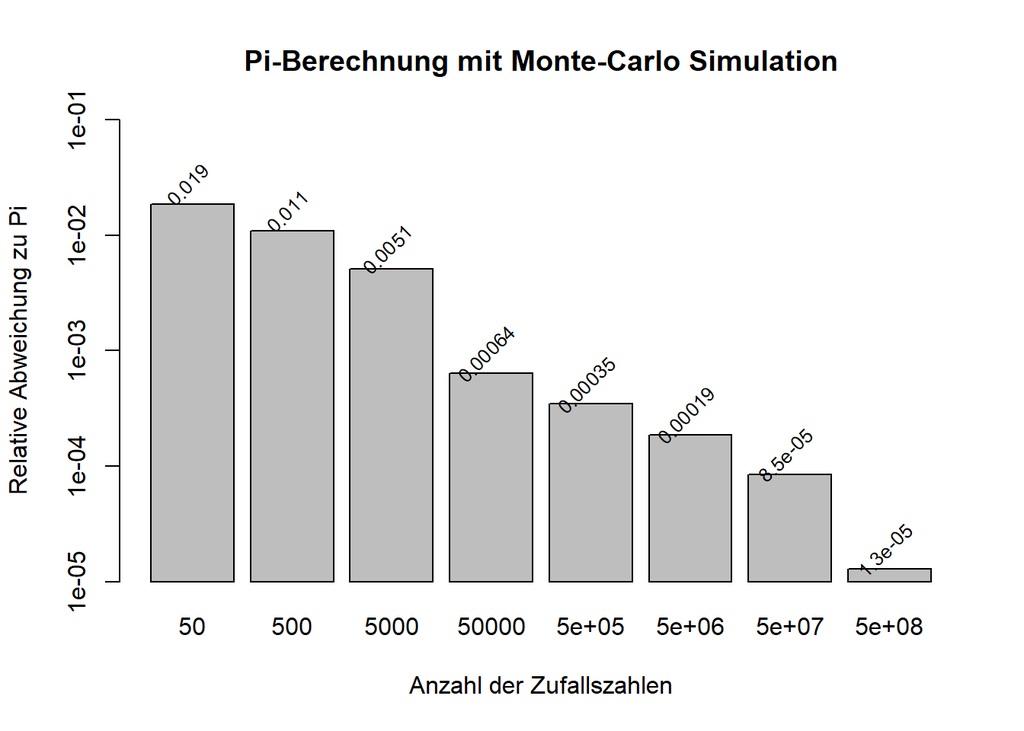

```r
pi.vec <- 4*Q.vec/(N.vec/2)
pidiff.vec <- abs(pi - pi.vec)
pidiff.vec <- pidiff.vec / pi # Relative Abweichung zu Pi


x <- pidiff.vec
pidiff.max <- 0.1
pidiff.min <- 10e-6
limit <- c(pidiff.min, pidiff.max)
bal <- barplot(x, ylim = limit, names.arg = N.vec/2, log="y", xlab="Anzahl der Zufallszahlen",ylab = "Relative Abweichung zu Pi", main = "Pi-Berechnung mit Monte-Carlo Simulation")

#axis(2, at = c(0.001, 0.1, 0.5, 1, 20, 50, 100), labels = c("1e-3", "1e-2", 5, 10, 20, 50, 100))
lab = signif(x, 2)
x_pos = N.vec/2

text(bal, y=x+x*0.003, labels =lab, pos=3, cex=.80, srt=45)
```

Mit 5x10^8 Zufallszahlen rechnet mein PC etwa 3 Minuten. Mit 5x10^7 wenige Sekunden. Der Zugewinn an genaugigkeit ist hierbei recht gering. Die relative Abweichung sinkt um nur

```r
pidiff.vec[7] - pidiff.vec[8]
```

```
## [1] 7.167983e-05
```

Daher wird hier abgebrochen. Die längere Rechendauer rechtfertig nicht mehr das nur marginal besser werdende Ergebnis.